# Ejercicios

Alejandra Fuentes y Santiago Tinoco

2026-08-15

# Ejercicio 1

A partir del dataset df, el cual trata de los incendios forestales, realice las siguientes tareas:

1. Filtrar los registros para incluir únicamente los incendios ocurridos en el estado de Idaho.
2. Seleccionar únicamente las columnas YEAR_, CAUSE y TOTALACRES.
3. Renombrar estas columnas con nombres más claros y descriptivos.
4. Agrupar la información por CAUSE y YEAR_.
5. Resumir el total de acres quemados para cada combinación de causa y año.
6. Elaborar una visualización que muestre los resultados de manera clara.

```r
library(tidyverse)
library(dplyr)
library(readr)

df_csv <- read_csv("StudyArea.csv")
df_idaho <- df_csv %>%
  filter(STATE == "Idaho") %>%
  select(YEAR_, CAUSE, TOTALACRES) %>%
  rename(Año = YEAR_, Causa = CAUSE, Acres_Quemados = TOTALACRES) %>%
  group_by(Causa, Año) %>%
  summarise(Total_Acres = sum(Acres_Quemados, na.rm = TRUE), .groups = 'keep') -> resumen

knitr::kable(resumen)
```

| Causa | Año | Total_Acres |
| --- | --- | --- |
| Human | 1980 | 71974.70 |
| Human | 1981 | 219362.40 |
| Human | 1982 | 34016.20 |
| Human | 1983 | 48242.50 |
| Human | 1984 | 36837.80 |
| Human | 1985 | 68035.30 |
| Human | 1986 | 43180.90 |
| Human | 1987 | 35128.40 |
| Human | 1988 | 810403.30 |
| Human | 1989 | 28021.60 |
| Human | 1990 | 103058.60 |
| Human | 1991 | 19940.40 |
| Human | 1992 | 212782.80 |
| Human | 1993 | 4113.10 |
| Human | 1994 | 299453.50 |
| Human | 1995 | 58544.50 |
| Human | 1996 | 156216.60 |
| Human | 1997 | 9484.10 |
| Human | 1998 | 28840.80 |
| Human | 1999 | 59034.70 |
| Human | 2000 | 87020.00 |
| Human | 2001 | 40137.30 |
| Human | 2002 | 7124.80 |
| Human | 2003 | 90178.59 |
| Human | 2004 | 4253.56 |
| Human | 2005 | 163203.90 |
| Human | 2006 | 161153.42 |
| Human | 2007 | 141901.02 |
| Human | 2008 | 35992.38 |
| Human | 2009 | 8585.01 |

[output cut: 66 more lines]

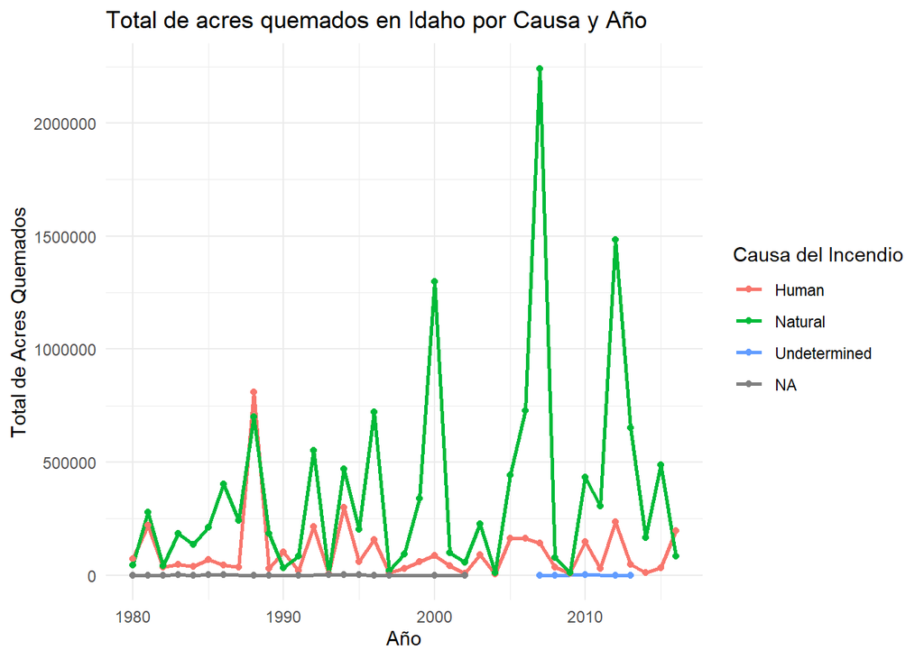

```r
# 2. Elaborar la visualización
ggplot(df_idaho, aes(x = as.numeric(Año), y = Total_Acres, color = Causa)) +
  geom_line(size = 1) +
  geom_point() +
  labs(title = "Total de acres quemados en Idaho por Causa y Año",
       x = "Año",
       y = "Total de Acres Quemados",
       color = "Causa del Incendio") +
  theme_minimal()
```

# Ejercicio 2

Trabajaremos con el conjunto de datos de 120 años de historia olímpica adquirido por Randi Griffin en Randi-Griffin y puesto a disposición en athlete_events. Su tarea consiste en identificar los cinco deportes más importantes según el mayor número de medallas otorgadas en el año 2016, y luego realizar el siguiente análisis:

1. Genere una tabla que indique el número de medallas concedidas en cada uno de los cinco principales deportes en 2016.
2. Elabore una tabla que muestre la distribución de la edad de los ganadores de medallas en los cinco principales deportes en 2016.
3. Identifique qué equipos nacionales ganaron el mayor número de medallas en los cinco principales deportes en 2016.
4. Presente un resumen de la tendencia del peso de los atletas masculinos y femeninos ganadores en los cinco principales deportes en 2016.

```r
datos <- read_csv("athlete_events.csv")
datos_2016 <- datos %>%
  filter(Year == 2016, !is.na(Medal))

# Top 5 deportes
medallas_deporte <- datos_2016 %>%
  count(Sport, name = "Numero_medallas") %>%
  arrange(desc(Numero_medallas))

top_5 <- medallas_deporte %>%
  slice_head(n = 5)

knitr::kable(top_5)
```

| Sport | Numero_medallas |
| --- | --- |
| Athletics | 192 |
| Swimming | 191 |
| Rowing | 144 |
| Football | 106 |
| Hockey | 99 |

```r
# Distribucion de edades
datos_top5 <- datos_2016 %>%
  filter(Sport %in% top_5$Sport)

distribucion_edad <- datos_top5 %>%
  filter(!is.na(Age)) %>%
  count(Sport, Age, name = "Numero_atletas") %>%
  arrange(Sport, Age)

knitr::kable(distribucion_edad)
```

| Sport | Age | Numero_atletas |
| --- | --- | --- |
| Athletics | 19 | 3 |
| Athletics | 20 | 9 |
| Athletics | 21 | 12 |
| Athletics | 22 | 11 |
| Athletics | 23 | 10 |
| Athletics | 24 | 25 |
| Athletics | 25 | 19 |
| Athletics | 26 | 21 |
| Athletics | 27 | 14 |
| Athletics | 28 | 5 |
| Athletics | 29 | 15 |
| Athletics | 30 | 15 |
| Athletics | 31 | 10 |
| Athletics | 32 | 8 |
| Athletics | 33 | 6 |
| Athletics | 34 | 4 |
| Athletics | 35 | 1 |
| Athletics | 37 | 3 |
| Athletics | 40 | 1 |
| Football | 17 | 2 |
| Football | 18 | 3 |
| Football | 19 | 6 |
| Football | 20 | 11 |
| Football | 21 | 14 |
| Football | 22 | 15 |
| Football | 23 | 11 |
| Football | 24 | 4 |
| Football | 25 | 4 |
| Football | 26 | 3 |
| Football | 27 | 7 |

[output cut: 64 more lines]

```r
# Equipo con más medallas
medallas_pais_deporte <- datos_top5 %>%
  count(Sport, Team, NOC, name = "Numero_medallas") %>%
  arrange(Sport, desc(Numero_medallas))

pais_lider_deporte <- medallas_pais_deporte %>%
  group_by(Sport) %>%
  slice_max(order_by = Numero_medallas, n = 1, with_ties = FALSE) %>%
  ungroup()

knitr::kable(pais_lider_deporte)
```

| Sport | Team | NOC | Numero_medallas |
| --- | --- | --- | --- |
| Athletics | United States | USA | 46 |
| Football | Germany | GER | 35 |
| Hockey | Germany | GER | 33 |
| Rowing | Great Britain | GBR | 26 |
| Swimming | United States | USA | 71 |

```r
# Tendencia peso promedio
peso_promedio <- datos_top5 %>%
  filter(!is.na(Weight)) %>%
  group_by(Sport, Sex) %>%
  summarise(
    Peso_promedio = mean(Weight),
    .groups = "drop"
  )

knitr::kable(peso_promedio)
```

| Sport | Sex | Peso_promedio |
| --- | --- | --- |
| Athletics | F | 62.57895 |
| Athletics | M | 79.07447 |
| Football | F | 62.96296 |
| Football | M | 75.72549 |
| Hockey | F | 63.06122 |
| Hockey | M | 78.38000 |
| Rowing | F | 71.76667 |
| Rowing | M | 88.83333 |
| Swimming | F | 66.19588 |
| Swimming | M | 83.40860 |

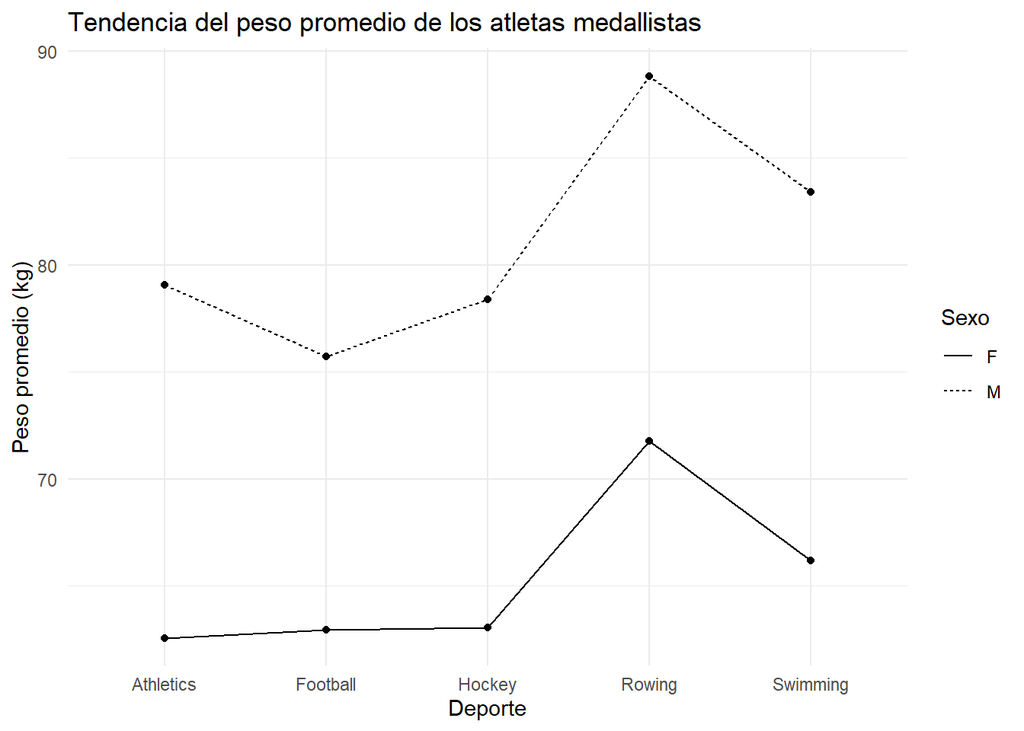

```r
ggplot(peso_promedio, aes(x = Sport, y = Peso_promedio, group = Sex, linetype = Sex)) +
  geom_line() +
  geom_point() +
  labs(
    title = "Tendencia del peso promedio de los atletas medallistas",
    x = "Deporte",
    y = "Peso promedio (kg)",
    linetype = "Sexo"
  ) +
  theme_minimal()
```

# Ejercicio 3

Considere el conjunto de datos us_state_population.tsv ubicado en la carpeta de datos de Python de github. Repita el procedimiento planteado en cada ítem de esta sección para obtener el nuevo dataframe con las nuevas columnas Year y Population. Realice unión y separación utilizando las columnas State y Code.

## Uso de Gather()

```r
df <- read_tsv("us_state_population.tsv", show_col_types = FALSE)

knitr::kable(df)
```

| State | Code | 2010 | 2011 | 2012 | 2013 | 2014 | 2015 | 2016 | 2017 | 2018 |
| --- | --- | --- | --- | --- | --- | --- | --- | --- | --- | --- |
| Alabama | AL | 4785448 | 4798834 | 4815564 | 4830460 | 4842481 | 4853160 | 4864745 | 4875120 | 4887871 |
| Alaska | AK | 713906 | 722038 | 730399 | 737045 | 736307 | 737547 | 741504 | 739786 | 737438 |
| Arizona | AZ | 6407774 | 6473497 | 6556629 | 6634999 | 6733840 | 6833596 | 6945452 | 7048876 | 7171646 |
| Arkansas | AR | 2921978 | 2940407 | 2952109 | 2959549 | 2967726 | 2978407 | 2990410 | 3002997 | 3013825 |
| California | CA | 37320903 | 37641823 | 37960782 | 38280824 | 38625139 | 38953142 | 39209127 | 39399349 | 39557045 |
| Colorado | CO | 5048281 | 5121771 | 5193721 | 5270482 | 5351218 | 5452107 | 5540921 | 5615902 | 5695564 |
| Connecticut | CT | 3579125 | 3588023 | 3594395 | 3594915 | 3594783 | 3587509 | 3578674 | 3573880 | 3572665 |
| Delaware | DE | 899595 | 907316 | 915188 | 923638 | 932596 | 941413 | 949216 | 957078 | 967171 |
| District of Columbia | DC | 605085 | 619602 | 634725 | 650431 | 662513 | 675254 | 686575 | 695691 | 702455 |
| Florida | FL | 18845785 | 19093352 | 19326230 | 19563166 | 19860330 | 20224249 | 20629982 | 20976812 | 21299325 |
| Georgia | GA | 9711810 | 9801578 | 9901496 | 9973326 | 10069001 | 10181111 | 10304763 | 10413055 | 10519475 |
| Hawaii | HI | 1363963 | 1379252 | 1394905 | 1408453 | 1414862 | 1422484 | 1428105 | 1424203 | 1420491 |
| Idaho | ID | 1570773 | 1583828 | 1595441 | 1611530 | 1631479 | 1651523 | 1682930 | 1718904 | 1754208 |
| Illinois | IL | 12840762 | 12867291 | 12884119 | 12898269 | 12888962 | 12864342 | 12826895 | 12786196 | 12741080 |
| Indiana | IN | 6490436 | 6516045 | 6537640 | 6568367 | 6593533 | 6608296 | 6633344 | 6660082 | 6691878 |
| Iowa | IA | 3050767 | 3066054 | 3076097 | 3093078 | 3109504 | 3121460 | 3131785 | 3143637 | 3156145 |
| Kansas | KS | 2858213 | 2869035 | 2885361 | 2893510 | 2900896 | 2909502 | 2911263 | 2910689 | 2911505 |
| Kentucky | KY | 4348200 | 4369488 | 4386381 | 4404817 | 4414483 | 4425999 | 4438229 | 4453874 | 4468402 |
| Louisiana | LA | 4544532 | 4575184 | 4600814 | 4624577 | 4644204 | 4664851 | 4678215 | 4670818 | 4659978 |
| Maine | ME | 1327632 | 1328150 | 1327691 | 1328196 | 1330760 | 1328484 | 1331370 | 1335063 | 1338404 |
| Maryland | MD | 5788642 | 5838991 | 5887072 | 5923704 | 5958165 | 5986717 | 6004692 | 6024891 | 6042718 |
| Massachusetts | MA | 6566431 | 6613149 | 6663158 | 6713944 | 6763652 | 6795891 | 6826022 | 6863246 | 6902149 |
| Michigan | MI | 9877535 | 9881521 | 9896930 | 9913349 | 9930589 | 9932573 | 9951890 | 9976447 | 9995915 |
| Minnesota | MN | 5310843 | 5345668 | 5376550 | 5413693 | 5451522 | 5482503 | 5523409 | 5568155 | 5611179 |
| Mississippi | MS | 2970536 | 2978470 | 2983767 | 2988797 | 2990623 | 2988693 | 2988298 | 2989663 | 2986530 |
| Missouri | MO | 5995976 | 6009641 | 6024081 | 6040658 | 6056293 | 6071745 | 6087203 | 6108612 | 6126452 |
| Montana | MT | 990722 | 997221 | 1003754 | 1013564 | 1021891 | 1030503 | 1040863 | 1053090 | 1062305 |
| Nebraska | NE | 1829536 | 1840538 | 1853323 | 1865414 | 1879522 | 1891507 | 1905924 | 1917575 | 1929268 |
| Nevada | NV | 2702464 | 2712799 | 2744566 | 2776972 | 2819012 | 2868666 | 2919772 | 2972405 | 3034392 |
| New Hampshire | NH | 1316777 | 1319815 | 1323962 | 1326408 | 1333223 | 1336294 | 1342373 | 1349767 | 1356458 |
| New Jersey | NJ | 8799624 | 8827783 | 8845483 | 8858362 | 8866780 | 8870869 | 8874516 | 8888543 | 8908520 |
| New Mexico | NM | 2064588 | 2080395 | 2087549 | 2092792 | 2090342 | 2090211 | 2092789 | 2093395 | 2095428 |
| New York | NY | 19400080 | 19498514 | 19574549 | 19628043 | 19656330 | 19661411 | 19641589 | 19590719 | 19542209 |
| North Carolina | NC | 9574293 | 9656754 | 9749123 | 9843599 | 9933944 | 10033079 | 10156679 | 10270800 | 10383620 |
| North Dakota | ND | 674710 | 685136 | 701116 | 721999 | 737382 | 754022 | 754353 | 755176 | 760077 |
| Ohio | OH | 11539327 | 11543463 | 11548369 | 11576576 | 11602973 | 11617850 | 11635003 | 11664129 | 11689442 |
| Oklahoma | OK | 3759632 | 3787821 | 3818600 | 3853205 | 3878367 | 3909831 | 3926769 | 3932640 | 3943079 |
| Oregon | OR | 3837532 | 3871728 | 3899118 | 3922908 | 3964106 | 4016918 | 4091404 | 4146592 | 4190713 |
| Pennsylvania | PA | 12711158 | 12744583 | 12766827 | 12776621 | 12789101 | 12785759 | 12783538 | 12790447 | 12807060 |
| Rhode Island | RI | 1053938 | 1053536 | 1054601 | 1055122 | 1056017 | 1056173 | 1057063 | 1056486 | 1057315 |
| South Carolina | SC | 4635656 | 4671422 | 4717112 | 4764153 | 4823793 | 4892253 | 4958235 | 5021219 | 5084127 |
| South Dakota | SD | 816165 | 823484 | 833496 | 842270 | 849088 | 853933 | 862890 | 873286 | 882235 |
| Tennessee | TN | 6355301 | 6397410 | 6451281 | 6493432 | 6540826 | 6590808 | 6645011 | 6708794 | 6770010 |
| Texas | TX | 25242679 | 25646227 | 26089620 | 26489464 | 26977142 | 27486814 | 27937492 | 28322717 | 28701845 |
| Utah | UT | 2775334 | 2814216 | 2853467 | 2897927 | 2937399 | 2982497 | 3042613 | 3103118 | 3161105 |
| Vermont | VT | 625880 | 626979 | 626063 | 626212 | 625218 | 625197 | 623644 | 624525 | 626299 |
| Virginia | VA | 8023680 | 8100469 | 8185229 | 8253053 | 8312076 | 8362907 | 8410946 | 8465207 | 8517685 |
| Washington | WA | 6742902 | 6821655 | 6892876 | 6962906 | 7052439 | 7163543 | 7294680 | 7425432 | 7535591 |
| West Virginia | WV | 1854214 | 1856074 | 1856764 | 1853873 | 1849467 | 1841996 | 1830929 | 1817048 | 1805832 |
| Wisconsin | WI | 5690479 | 5704755 | 5719855 | 5736952 | 5751974 | 5761406 | 5772958 | 5792051 | 5813568 |
| Wyoming | WY | 564483 | 567224 | 576270 | 582123 | 582548 | 585668 | 584290 | 578934 | 577737 |

```r
df2 = gather(df,
                "2010", "2011", "2012", "2013", "2014", "2015", "2016", "2017", "2018",
                key = "Año",
                value = "Población")
knitr::kable(head(df2, 5))
```

| State | Code | Año | Población |
| --- | --- | --- | --- |
| Alabama | AL | 2010 | 4785448 |
| Alaska | AK | 2010 | 713906 |
| Arizona | AZ | 2010 | 6407774 |
| Arkansas | AR | 2010 | 2921978 |
| California | CA | 2010 | 37320903 |

## Uso de Spread()

```r
df2b = spread(df2, key = "Año", value = "Población")
knitr::kable(head(df2b))
```

| State | Code | 2010 | 2011 | 2012 | 2013 | 2014 | 2015 | 2016 | 2017 | 2018 |
| --- | --- | --- | --- | --- | --- | --- | --- | --- | --- | --- |
| Alabama | AL | 4785448 | 4798834 | 4815564 | 4830460 | 4842481 | 4853160 | 4864745 | 4875120 | 4887871 |
| Alaska | AK | 713906 | 722038 | 730399 | 737045 | 736307 | 737547 | 741504 | 739786 | 737438 |
| Arizona | AZ | 6407774 | 6473497 | 6556629 | 6634999 | 6733840 | 6833596 | 6945452 | 7048876 | 7171646 |
| Arkansas | AR | 2921978 | 2940407 | 2952109 | 2959549 | 2967726 | 2978407 | 2990410 | 3002997 | 3013825 |
| California | CA | 37320903 | 37641823 | 37960782 | 38280824 | 38625139 | 38953142 | 39209127 | 39399349 | 39557045 |
| Colorado | CO | 5048281 | 5121771 | 5193721 | 5270482 | 5351218 | 5452107 | 5540921 | 5615902 | 5695564 |

## Uso de Unite()

```r
df3 = unite(df, Code_State_Name, Code, State)
knitr::kable(head(df3, 5))
```

| Code_State_Name | 2010 | 2011 | 2012 | 2013 | 2014 | 2015 | 2016 | 2017 | 2018 |
| --- | --- | --- | --- | --- | --- | --- | --- | --- | --- |
| AL_Alabama | 4785448 | 4798834 | 4815564 | 4830460 | 4842481 | 4853160 | 4864745 | 4875120 | 4887871 |
| AK_Alaska | 713906 | 722038 | 730399 | 737045 | 736307 | 737547 | 741504 | 739786 | 737438 |
| AZ_Arizona | 6407774 | 6473497 | 6556629 | 6634999 | 6733840 | 6833596 | 6945452 | 7048876 | 7171646 |
| AR_Arkansas | 2921978 | 2940407 | 2952109 | 2959549 | 2967726 | 2978407 | 2990410 | 3002997 | 3013825 |
| CA_California | 37320903 | 37641823 | 37960782 | 38280824 | 38625139 | 38953142 | 39209127 | 39399349 | 39557045 |

## Uso del Separate()

```r
df3b = separate(df3, "Code_State_Name", into= c("Abrev", "Estado"))
knitr::kable(head(df3b, 5))
```

| Abrev | Estado | 2010 | 2011 | 2012 | 2013 | 2014 | 2015 | 2016 | 2017 | 2018 |
| --- | --- | --- | --- | --- | --- | --- | --- | --- | --- | --- |
| AL | Alabama | 4785448 | 4798834 | 4815564 | 4830460 | 4842481 | 4853160 | 4864745 | 4875120 | 4887871 |
| AK | Alaska | 713906 | 722038 | 730399 | 737045 | 736307 | 737547 | 741504 | 739786 | 737438 |
| AZ | Arizona | 6407774 | 6473497 | 6556629 | 6634999 | 6733840 | 6833596 | 6945452 | 7048876 | 7171646 |
| AR | Arkansas | 2921978 | 2940407 | 2952109 | 2959549 | 2967726 | 2978407 | 2990410 | 3002997 | 3013825 |
| CA | California | 37320903 | 37641823 | 37960782 | 38280824 | 38625139 | 38953142 | 39209127 | 39399349 | 39557045 |